# Simulating clinical trials

Steve Simon

March 22, 2017

### Part 8. Modeling multi-center trials.

```
##     A  B  C  D  E  F  G  H  I  J  K  L  M  N   Z  t
## 1   0  0  0  0  0  0  0  0  1  1  0  0  0  0   2  1
## 2   0  0  0  0  0  0  2  0  3  2  3  0  0  0  10  2
## 3   1  1  1  0  1  5  2  0  3  4  6  0  1  0  25  3
## 4   1  1  3  0  2 11  3  0  3  5  9  0  2  0  40  4
## 5   1  1  3  0  2 12  7  0  3  7 11  0  2  0  49  5
## 6   2  1  4  0  3 14  8  0  4  8 17  0  2  0  63  6
## 7   4  2  5  0  4 17 10  0  4 11 21  0  7  0  85  7
## 8   5  3  5  0  4 19 13  0  6 14 22  0 11  0 102  8
## 9   7  3  7  0  5 20 15  0  8 16 25  0 13  0 119  9
## 10 10  5 10  0  6 23 18  0  8 18 27  0 20  0 145 10
## 11 10  6 12  0  9 24 18  0 10 20 33  0 21  0 163 11
## 12 11  7 14  0 10 27 20  0 12 22 36  0 23  0 182 12
## 13 12  8 15  0 11 27 21  0 12 23 40  0 25  0 194 13
## 14 14  9 17  0 11 28 22  1 12 25 41  0 27  0 207 14
```

[output cut: 42 more lines]

```
##     A  B  C  D   Z  t
## 1   1  3  0  0   4  1
## 2   2  5  0  0   7  2
## 3   3  7  4  2  16  3
## 4   3  7  5  3  18  4
## 5   3  9  7  5  24  5
## 6   5 12 10  8  35  6
## 7   7 12 11 10  40  7
## 8   7 15 12 13  47  8
## 9   7 15 13 15  50  9
## 10 10 16 14 16  56 10
## 11 11 18 15 17  61 11
## 12 12 18 16 19  65 12
## 13 12 20 17 21  70 13
## 14 14 21 17 22  74 14
## 15 14 22 17 24  77 15
## 16 16 24 18 25  83 16
## 17 16 25 18 27  86 17
## 18 18 27 20 28  93 18
## 19 20 27 21 30  98 19
## 20 20 29 21 30 100 20
## 21 22 29 24 31 106 21
## 22 23 31 24 33 111 22
## 23 23 35 25 35 118 23
## 24 27 37 27 36 127 24
```

There are several ways to model accrual in a hierarchical setting. A simple and easy to follow approach is to model deviations of each individual center from the overall accrual rate with a lognormal distribution. The lognormal distribution is a bit tricky to work. One definition of a lognormal random variable is a random variable where the logarithm of that random variable is normally distributed. So you can describe the lognormal distribution in terms of the mean, $\mu$, and standard deviation, $\sigma$, of the underlying normal distribution. Or you can describe it in terms of the geometric mean, $e^\mu$, and geometric standard deviation, $e^\sigma$.

Another tricky issue is that the arithmetic mean of a lognormal random variable is going to be larger than the geometric mean. If X is lognormal with parameters $\mu$ and $\sigma$, then the arithmetic mean is larger than the geometric mean by a multiplicative factor, $e^{0.5~\sigma^2}$.

In our setting, we want to make sure that the arithmetic mean of the lognormal center effects is always 1. So our lognormals will use a “fudge factor” of $\mu=-0.5~\sigma^2$.

It’s important to anchor these prior distributions to something concrete and observable. A simple numeric summary is the proportion of patients that are likely to come from your highest accruing center. Let’s look at an example with 14 centers. If the accrual rates were identical across all 14 centers, then the each center would contribute roughly 7% of the patients.

### Figure 8.1. How much variation is produced by different lognormal distributions?

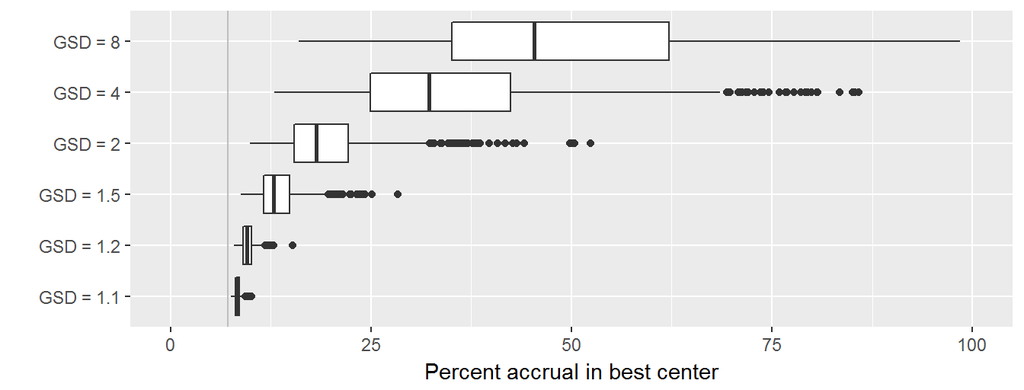

You decide after looking at these boxpots that a GSD around 1.5 is fairly representative of your experience with accrual in multi-center trials of this particular type and that a GSD of 2 represents the most extreme case you are likely to encounter.

### Figure 8.2. Prior distribution on the gsd.

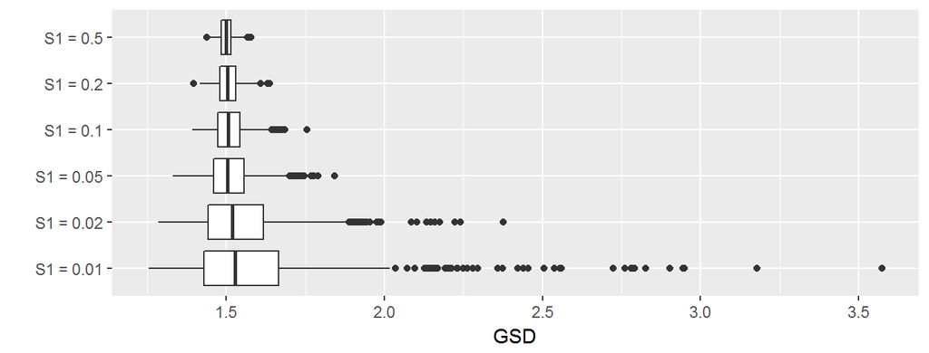

Now you need to specify a prior on the GSD that is centered around 1.5 and where most of the probability is for values below 2.

### Here’s what the code looks like for a hierarchical model.

```
## data {
##   int<lower=1>           N; // planned number of patients total
##   real<lower=0>          T; // planned duration of trial
##   real<lower=0, upper=1> S; // strength of prior for lambda
##   real<lower=0, upper=1> S1; // strength of prior for sigma
##   real<lower=0>          GSD; // geometric standard deviation of center effect
##   int<lower=1>           M; //number of centers
## }
## parameters {
##   real<lower=0> lambda; // overall rate
##   real<lower=0> sigma_sq; // between center variation
##   real<lower=0> eta[M]; // center effect
## }
## transformed parameters {
##   real<lower=0> sigma;
##   real<lower=1> gsd;
##   sigma = sqrt(sigma_sq);
##   gsd = exp(sigma);
## }
## model {
##   lambda ~ gamma(N*S, T*S);
##   eta ~ lognormal(-0.5*sigma^2, sigma);
##   sigma_sq ~ inv_gamma(N*S1, N*S1*log(GSD)^2);
## }
## generated quantities {
##   real <lower=0, upper=100> max_pct;
##   real<lower=0> Mstar[M];
##   real<lower=0> Nstar;
##   for (i in 1:M) {
##     Mstar[i] = poisson_rng(T*lambda*eta[i]/M);
##   }
##   Nstar = sum(Mstar);
##   max_pct = 100*max(Mstar) / Nstar;
## }
```

### Figure 8.3. Estimated total sample size prior to start of clinical trial.

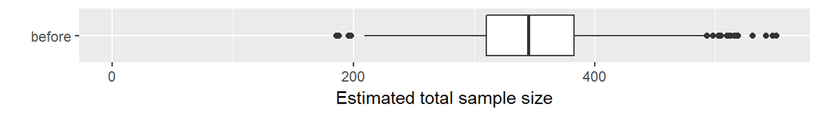

### Figure 8.4. Relationship of prior distributions to estimated total sample size.

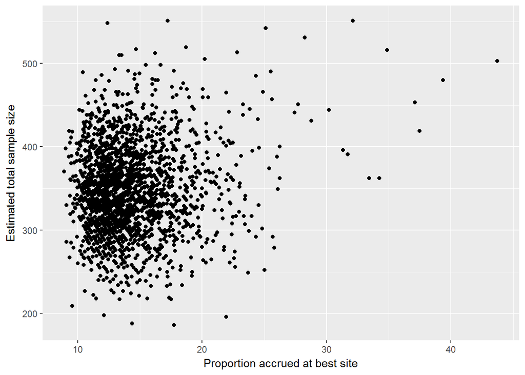

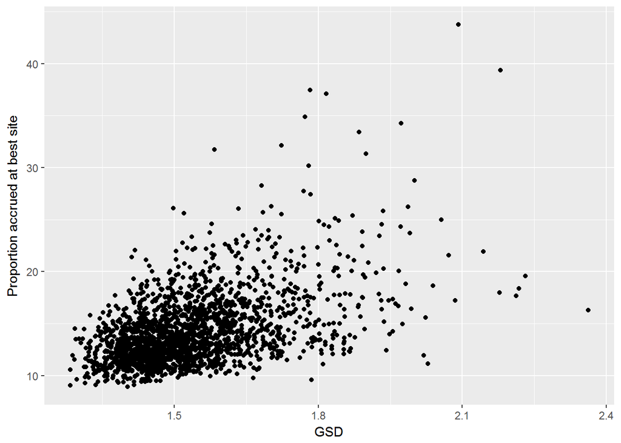

```
##         term    estimate   std.error     conf.low   conf.high
## 1     lambda   0.3195981  0.02519010   0.27225615   0.3695849
## 2   sigma_sq   0.1895409  0.08216227   0.08643257   0.4021161
## 3     eta[1]   0.9963012  0.42852793   0.39033874   2.0892525
## 4     eta[2]   0.9975998  0.44260811   0.38268211   2.0810712
## 5     eta[3]   0.9963394  0.43604133   0.37939803   2.0871818
## 6     eta[4]   0.9855542  0.43903853   0.38557469   2.0953420
## 7     eta[5]   0.9988708  0.45891774   0.38722950   2.0410533
## 8     eta[6]   0.9839569  0.42875273   0.38789631   2.0342536
## 9     eta[7]   1.0017048  0.45742144   0.36422563   2.0958901
## 10    eta[8]   0.9895484  0.45463769   0.36665188   2.1102458
## 11    eta[9]   0.9940765  0.44773722   0.38342257   2.1020079
## 12   eta[10]   0.9950651  0.44692821   0.37911528   2.0767523
## 13   eta[11]   1.0073329  0.48888180   0.36651277   2.1667793
## 14   eta[12]   1.0059853  0.49676046   0.38106923   2.1306719
```

[output cut: 20 more lines]

```
## [1] 14
```

```
##     A B  C D  E  F  G H  I  J  K L  M N
## 14 14 9 17 0 11 28 22 1 12 25 41 0 27 0
```

```
##         term    estimate   std.error
## 1     lambda   0.3191872  0.02439053
## 2   sigma_sq   0.1941686  0.08544536
## 3     eta[1]   1.0110039  0.48345337
## 4     eta[2]   0.9876655  0.47736485
## 5     eta[3]   1.0021960  0.48280899
## 6     eta[4]   0.9934917  0.44287082
## 7     eta[5]   0.9927451  0.45010174
## 8     eta[6]   1.0188599  0.47499009
## 9     eta[7]   0.9936874  0.43816828
## 10    eta[8]   1.0120365  0.47564101
## 11    eta[9]   1.0128147  0.48196667
## 12   eta[10]   0.9938179  0.45985739
## 13   eta[11]   0.9815941  0.43249432
## 14   eta[12]   0.9928182  0.45103417
```

[output cut: 20 more lines]

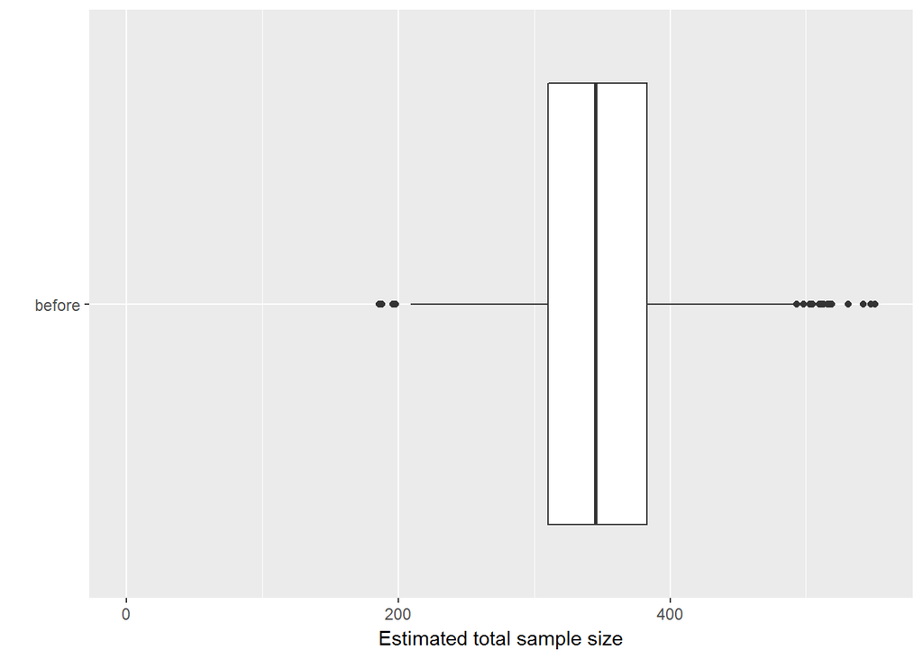